# 1_nuseds_collation

Bruno S. Carturan, Eric Hertz, Stephanie J. Peacock

The goal of the script is to merge the two constituent datasets **all_areas_nuseds** (referred to as **NUSEDS**) and **conservation_unit_census_sites** (referred to as **CUSS**) so each time series in **NUSEDS** (i.e., fish counts associated to a unique populations, characterized by a unique `IndexId`/`POP_ID` & `GFE_ID` association) can be attributed to a unique conservation unit (CU) in **CUSS** (characterized by `CU_NAME` and `FULL_CU_IN`). But there are multiple inconsistencies between the two datasets that lead to discard a significant amount of data points in **NUSEDS**, unless fixes are implemented. This script is a attempt to implement such fixes.

The dataset version corresponding to this script is:

Fisheries and Oceans Canada. 2025. NuSEDS - New Salmon Escapement Database System. Pacific Biological Station. Updated in 2025-11-03 and downloaded in January 01, 2026, from https://open.canada.ca/data/en/dataset/c48669a3-045b-400d-b730-48aafe8c5ee6.

**IMPORTANT NOTE:** This is the script that PSF maintains actively and it is updated annually as new versions of NuSEDS are released. The corresponding script used in [Atkinson et al. 2025. Monitoring for fisheries or for fish? Declines in monitoring of salmon spawners continue despite a conservation crisis](https://doi.org/10.1139/cjfas-2024-0387) is accessible at: a_nuseds_collation.Rmd.

# 1 Import datasets

The **NUSEDS** (all_areas_nuseds) and **CUSS** (conservation_unit_census_sites) datasets are imported and duplicated rows are removed. The columns considered for NuSEDS are related to the population, location, fish counts and year of assessment:

```
## [1] "File imported: All Areas NuSEDS_20251103.csv ; Date modified: 2026-01-08 09:04:18.530449"
```

```
## [1] "File imported: Conservation Unit Census Sites_20250528.csv ; Date modified: 2026-01-08 09:09:46.487137"
```

The list of conservation units (CUs) as shown in the Pacific Salmon Explorer ([PSE](https://www.salmonexplorer.ca/)) is imported. The columns `cu_name_pse` and `cu_name_dfo` correspond to `CU_NAME` in **CUSS**, `cu_index` corresponds to `FULL_CU_INDEX`.

```
##   region species_name species_qualified cuid             cu_name_pse
## 1 Skeena      Sockeye               SEL  171                Alastair
## 2 Skeena      Sockeye               SEL  174           Ecstall/Lower
## 3 Skeena      Sockeye               SEL  175                Johnston
## 4 Skeena      Sockeye               SEL  176             Kitsumkalum
## 5 Skeena      Sockeye               SEL  177                 Lakelse
## 6 Skeena      Sockeye               SEL  172 Mcdonell/Dennis/Aldrich
##     cu_name_dfo  cu_index
## 1      Alastair SEL-20-01
## 2 Ecstall/Lower SEL-20-04
## 3      Johnston SEL-20-05
## 4   Kitsumkalum SEL-20-06
## 5       Lakelse SEL-20-07
## 6       Aldrich SEL-20-02
```

The **DFO file of the stream locations and coordinates** (emailed from Wu Zhipeng, DFO, 09/04/2024) is imported. The columns `NME` and `ID` correspond to `SYSTEM_SITE` and `GFE_ID` in CUSS, respectively.

```
## # A tibble: 6 × 4
##   NME               ID X_LONGT           Y_LAT
##   <chr>          <dbl> <chr>             <chr>
## 1 STANLEY CREEK   1557 -132.691420767338 53.9746116925906
## 2 DAVIDSON CREEK  1558 -132.682181062338 53.9544135568635
## 3 NADEN RIVER     1559 -132.672499482506 53.9448571061959
## 4 LIGNITE CREEK   1560 -132.601901312242 53.97114945092
## 5 OTUN RIVER      1561 -132.260106013    54.07328672
## 6 BILL CREEK      1562 -132.395009112518 53.7494926521361
```

The **DFO hatchery data file** (emailed from Brock Ramshaw, DFO, 03/07/2023) is imported because it contains `GFE_ID` (i.e., `STOCK_GFE_ID` and `REL_GFE_ID`) and coordinates that are missing in the above DFO stream location file:

```
## # A tibble: 6 × 8
##   STOCK_GFE_ID STOCK_WATERBODY_NAME STOCK_LATITUDE STOCK_LONGITUDE REL_GFE_ID
##          <dbl> <chr>                         <dbl>           <dbl>      <dbl>
## 1         1001 TANKEEAH RIVER                 52.3           -128.       1001
## 2         1001 TANKEEAH RIVER                 52.3           -128.       1001
## 3         1001 TANKEEAH RIVER                 52.3           -128.      11611
## 4         1001 TANKEEAH RIVER                 52.3           -128.      11611
## 5         1001 TANKEEAH RIVER                 52.3           -128.       1001
## 6         1001 TANKEEAH RIVER                 52.3           -128.       1001
## # ℹ 3 more variables: REL_WATERBODY_NAME <chr>, REL_LATITUDE <dbl>,
## #   REL_LONGITUDE <dbl>
```

The regions and CUs shape files as defined in the PSE are imported:

# 2 Initial modifications

We remove from **NUSEDS** and **CUSS** data related to steelhead, Atlantic salmon and Kokanee salmon, corresponding to 980 rows and 133 populations (`POP_ID`) in **NUSEDS** and 0 in **CUSS**.

We create the column `IndexId`, which the the combination of the species acronym (i.e., CO, CM, CN, PKO, PKE, SX) and `POP_ID`:

```
## [1] "CN_48442"  "CO_590"    "CO_1794"   "CO_1844"   "CO_2172"   "PKE_51264"
```

We create the column `MAX_ESTIMATE` which is the maximum value of the fish count columns:

```
## [1] "NATURAL_ADULT_SPAWNERS"    "NATURAL_JACK_SPAWNERS"
## [3] "NATURAL_SPAWNERS_TOTAL"    "ADULT_BROODSTOCK_REMOVALS"
## [5] "JACK_BROODSTOCK_REMOVALS"  "TOTAL_BROODSTOCK_REMOVALS"
## [7] "OTHER_REMOVALS"            "TOTAL_RETURN_TO_RIVER"
```

# 3 Fixes on NUSEDS and CUSS

The major issue in NuSEDS is the discrepancy between the two datasets. Normally, there should be the same population references (i.e., unique `IndexId`/`POP_ID` & `GFE_ID` combinations). But there are 11591 unique population references in **NUSEDS** and only 7149 in **CUSS**. Additionally, there are 4447 references in **NUSEDS** that are not in **CUSS** and 5 that are in **CUSS** but not in **NUSEDS**. This section consists in solving these discrepancies so that the same population references are present in both datasets.

## 3.1 Duplicated rows

There are 60 duplicated rows in **NUSEDS** when considering the following fields:

```
##  [1] "SPECIES"                   "POP_ID"
##  [3] "GFE_ID"                    "Year"
##  [5] "NATURAL_ADULT_SPAWNERS"    "NATURAL_JACK_SPAWNERS"
##  [7] "NATURAL_SPAWNERS_TOTAL"    "ADULT_BROODSTOCK_REMOVALS"
##  [9] "JACK_BROODSTOCK_REMOVALS"  "TOTAL_BROODSTOCK_REMOVALS"
## [11] "OTHER_REMOVALS"            "TOTAL_RETURN_TO_RIVER"
## [13] "ENUMERATION_METHODS"       "ESTIMATE_CLASSIFICATION"
```

```
##    SPECIES POP_ID GFE_ID Year MAX_ESTIMATE
## 1  Sockeye  44565   2489 1997           NA
## 2  Sockeye  44565   2489 1998           NA
## 3  Sockeye  44565   2489 2001           NA
## 4  Sockeye  44565   2489 2002           NA
## 5     Coho  44567   2489 1995           NA
## 6     Coho  44567   2489 1996           NA
## 7     Coho  44567   2489 1997            1
## 8     Coho  44567   2489 1998           12
## 9     Coho  44567   2489 1999           NA
## 10    Coho  44567   2489 2000           NA
## 11    Coho  44567   2489 2001           NA
## 12    Coho  44567   2489 2002           NA
## 13    Coho  44567   2489 2003           NA
## 14    Coho  44567   2489 2004           NA
```

[output cut: 46 more lines]

We assume these are real duplicated rows in **NUSEDS** so we remove them.

For **CUSS**, 0 duplicated rows are found:

```
##  [1] GFE_ID              CENSUS_SITE         GFE_TYPE
##  [4] SPECIES_QUALIFIED   Y_LAT               X_LONGT
##  [7] FAZ_ACRO            MAZ_ACRO            JAZ_ACRO
## [10] CU_NAME             CU_ACRO             CU_LAT
## [13] CU_LONGT            CU_TYPE             CU_INDEX
## [16] FULL_CU_IN          SBJ_ID              POP_ID
## [19] IS_INDICATOR        CMNTS               EFFECTIVE_DT
## [22] WATERSHED_CDE       FWA_WATERSHED_CDE   coordinates_changed
## [25] SPECIES             species_acronym_ncc IndexId
## <0 rows> (or 0-length row.names)
```

These rows (if any) are removed as well.

## 3.2 Conflictual counts in NUSEDS

There are 2 instances where multiple `MAX_ESTIMATE` values are available in a same `Year` for a given population:

```
##    IndexId GFE_ID Year MAX_ESTIMATE        ESTIMATE_METHOD
## 1 CN_45164   2224 2023  3957.000000             Sonar-ARIS
## 2 CN_45164   2224 2023   462.000000       Peak Live + Dead
## 3 CN_46447    241 2016   494.000000 Calibrated Time Series
## 4 CN_46447    241 2016   475.414455 Calibrated Time Series
##       ESTIMATE_CLASSIFICATION
## 1     TRUE ABUNDANCE (TYPE-1)
## 2 RELATIVE ABUNDANCE (TYPE-4)
## 3 RELATIVE ABUNDANCE (TYPE-4)
## 4 RELATIVE ABUNDANCE (TYPE-4)
```

For `CN_45164`, we keep the observation with the largest count because the method associated is better (TYPE 1 vs. TYPE 4).

For `CN_46447`, there are different `CREATED_DTT` and `UPDATED_DTT` for the two entries:

```
##    IndexId GFE_ID Year NATURAL_ADULT_SPAWNERS        ESTIMATE_METHOD
## 1 CN_46447    241 2016             494.000000 Calibrated Time Series
## 2 CN_46447    241 2016             475.414455 Calibrated Time Series
##   CREATED_DTT UPDATED_DTT
## 1   06-AUG-21   26-MAR-25
## 2   16-APR-24
```

We keep the observation with the most recent entry: the one with `UPDATED_DTT` = 26-MAR-25.

## 3.3 Location without Adaptive Zone data in CUSS

There is one instance of a location (`GFE_ID`) that does not have values for `FAZ_ACRO`,`MAZ_ACRO`,`JAZ_ACRO`:

```
##       CENSUS_SITE GFE_ID FAZ_ACRO MAZ_ACRO JAZ_ACRO
## 1 PUNTLEDGE RIVER   1156      EVI     GStr EVI+GStr
## 2 PUNTLEDGE RIVER   1156
```

We edit **CUSS** accordingly.

## 3.4 Missing coordinates in CUSS

There are 9 locations without coordinates in any of the source files and for which we have to define coordinates manually (cf., code to see the sources when available):

```
##                                     CENSUS_SITE     GFE_ID     X_LONGT
## 1                            NICOLA RIVER (DAM)      54282 -120.665873
## 2                            NICOLA RIVER (DOT)      54283 -121.315659
## 3                          BIRCH ISLAND CHANNEL      33045 -119.889197
## 4                            BLUE RIVER - UPPER 1921661712 -119.289006
## 5          MIDDLE NORTH THOMPSON RIVER MAINSTEM 1754239945 -119.701668
## 6                          PIG CHANNEL COMBINED  719256264  119.810014
## 7           UPPER NORTH THOMPSON RIVER MAINSTEM 2049268617 -119.177796
## 8 UPPER NORTH THOMPSON RIVER-MILEDGE CONFLUENCE      57041 -119.173514
## 9                       CHILCOTIN RIVER - UPPER       2462 -124.028396
##       Y_LAT
## 1 50.163045
## 2 50.424454
## 3 51.598602
## 4 52.112252
## 5 51.593091
## 6 51.579465
## 7 52.345236
## 8 52.281312
## 9 52.339295
```

## 3.5 Remove the IndexId & GFE_ID time series in NUSEDS with only NAs and/or 0s

We remove these time series to reduce the amount of cleaning to do after. There is the option to remove series with (1) only NAs and 0s or (2) only NAs.

Decision made:

```
## [1] "Time series uniqually made of NAs are removed (those also containing 0s are kept)."
```

This procedure removes 102104 rows in **NUSEDS**, corresponding to 24.4% of the original dataset.

The data removed concerns 4425 time series, which are referenced in `removed_all`:

```
##   IndexId GFE_ID dataset                   comment
## 1  CN_134   2615  NUSEDS Only NAs for MAX_ESTIMATE
## 2  SX_142   2615  NUSEDS Only NAs for MAX_ESTIMATE
## 3  CN_144   2624  NUSEDS Only NAs for MAX_ESTIMATE
## 4  SX_152   2624  NUSEDS Only NAs for MAX_ESTIMATE
## 5  CN_154   2625  NUSEDS Only NAs for MAX_ESTIMATE
## 6  SX_162   2625  NUSEDS Only NAs for MAX_ESTIMATE
```

Note that we do not remove the references of these series (i.e., their `IndexId` & `GFE_ID` association) in **CUSS** in order to not loose information.

## 3.6 Fix populations in NUSEDS that are not in CUSS

The goal is to look for each `IndexId/POP_ID` & `GFE_ID` series in **NUSEDS** that are not in **CUSS** and to proceed as follow:

1. The series with a `IndexId/POP_ID` associate with a `FULL_CU_IN` (field added in **NUSEDS** since 2025-11-03) are added to **CUSS**. The step might require to add a new `IndexId/POP_ID` and/or `GFE_ID` to **CUSS**.
2. The missing `FULL_CU_IN` (and consequently `CU_NAME` and other related fields) of the remaining series is found by intersecting the coordinates (`X_LONGT` and `Y_LAT`) associated with the `GFE_ID` with the PSE’s CUs’ shape files. Several `GFE_ID` are missing coordinates so we look in the DFO stream file and the DFO hatchery file as alternative sources. Once associated to a CU, these series are added to **CUSS**.

There are 264 `IndexId` & `GFE_ID` time series in **NUSEDS** whose references are not present in **CUSS**, among which 53 already have a `FULL_CU_IN`.

Among the 194 locations (`GFE_ID`) associated to these series, 127 are present with coordinates in **CUSS**, 40 had to be found in the DFO file of the stream locations, 4 were found in the DFO hatchery file and 23 were not found anywhere. In the next section, we attribute coordinates to the latter manually.

### 3.6.1 GFE_ID with missing X_LONGT and Y_LAT

There are 23 locations with coordinates we manually defined using Google Maps or any resource we could find.

There are two *Clearwater Creek* `WATERBODY` associated to *Phillips River (Campbell River Area)* `POPULATION` in **NUSEDS**:

```
##          WATERBODY    GFE_ID
## 1 CLEARWATER CREEK      2618
## 2 Clearwater Creek 446068199
```

None of the two `GFE_ID` are in **CUSS**

```r
cond <- conservation_unit_census_sites$GFE_ID %in% c(2618,446068199)
show <- unique(conservation_unit_census_sites[cond,c("CENSUS_SITE","GFE_ID","X_LONGT","Y_LAT")])
show <- as.data.frame(show)
rownames(show) <- NULL
show
```

```
## [1] CENSUS_SITE GFE_ID      X_LONGT     Y_LAT
## <0 rows> (or 0-length row.names)
```

One of them is in the **DFO file of the stream locations**:

```r
cond <- DFO_All_Streams_Segments$ID %in% c(2618,446068199)
show <- unique(DFO_All_Streams_Segments[cond,c("NME","ID","X_LONGT","Y_LAT")])
show <- as.data.frame(show)
rownames(show) <- NULL
show
```

```
##                NME   ID        X_LONGT         Y_LAT
## 1 CLEARWATER CREEK 2618 -125.276480824 50.6158337647
```

By comparing all the time series having the same `indexId/POP_ID` with those two `GFE_ID`, we can see all of them can be merged:

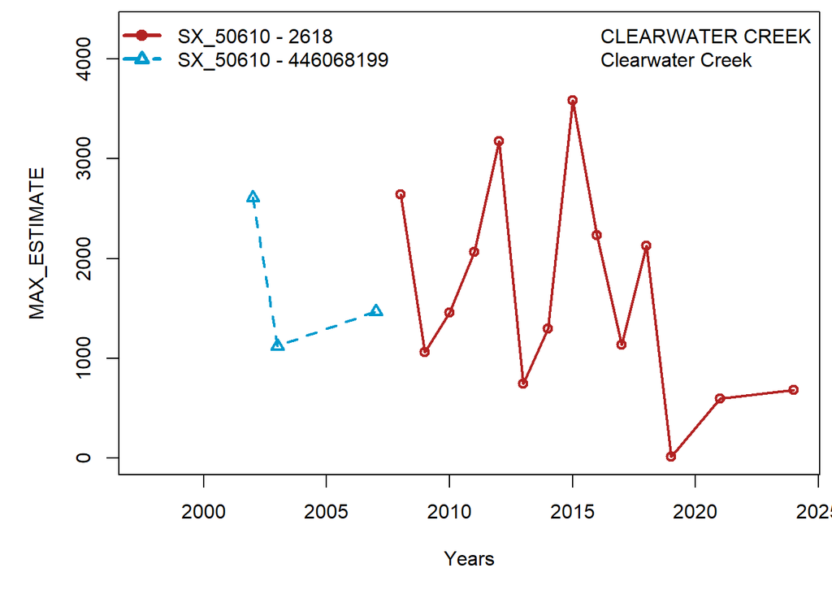

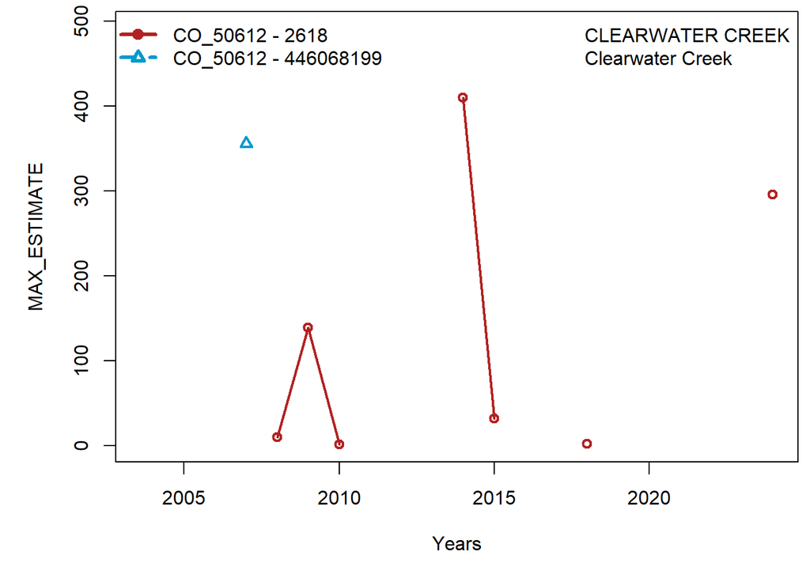

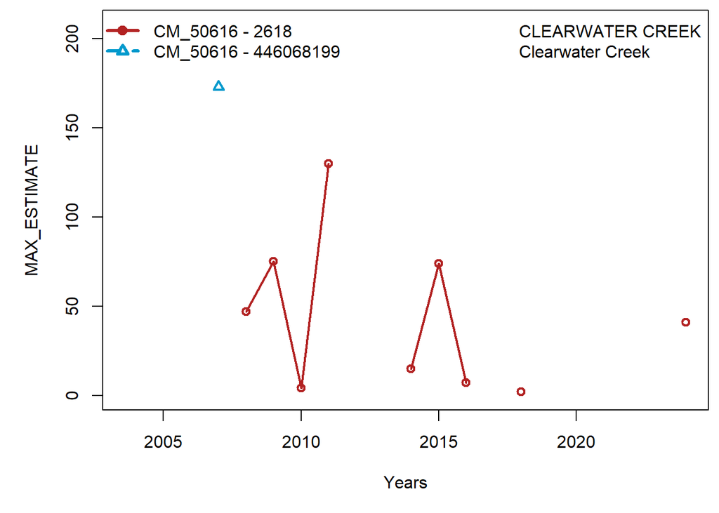

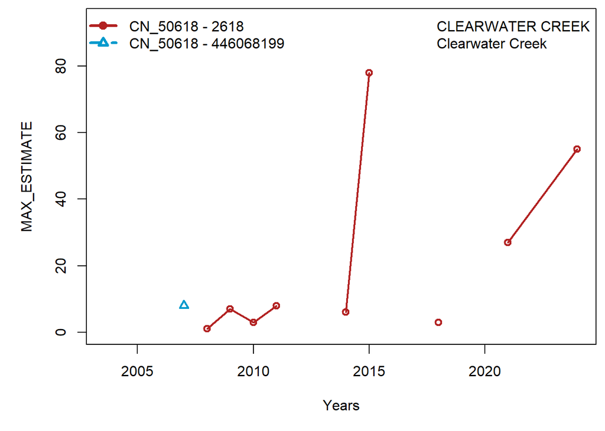

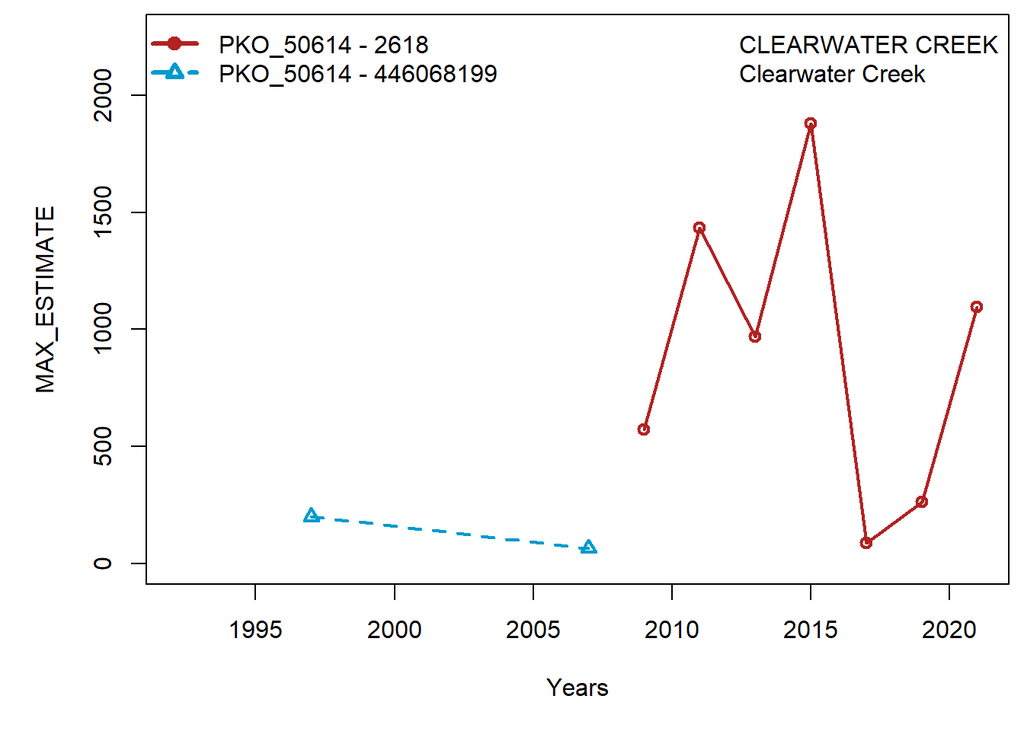

We consequently assume that the two locations are the same and we merge the time time series by replacing the `GFE_ID` value without coordinates (`446068199`) by the one with coordinates (`2618`) in **NUSEDS**.

```
## [1] "Series SX_50610 - 446068199 merged to series SX_50610 - 2618 in NUSEDS"
## [1] "3 rows were edited in all_areas_nuseds at the following fields: AREA, WATERBODY, GAZETTED_NAME, LOCAL_NAME_1, LOCAL_NAME_2, WATERSHED_CDE, WATERBODY_ID, GFE_ID, FWA_WATERSHED_CDE"
## [1] ""
## [1] "Series CO_50612 - 446068199 merged to series CO_50612 - 2618 in NUSEDS"
## [1] "1 rows were edited in all_areas_nuseds at the following fields: AREA, WATERBODY, GAZETTED_NAME, LOCAL_NAME_1, LOCAL_NAME_2, WATERSHED_CDE, WATERBODY_ID, GFE_ID, FWA_WATERSHED_CDE"
## [1] ""
## [1] "Series CM_50616 - 446068199 merged to series CM_50616 - 2618 in NUSEDS"
## [1] "1 rows were edited in all_areas_nuseds at the following fields: AREA, WATERBODY, GAZETTED_NAME, LOCAL_NAME_1, LOCAL_NAME_2, WATERSHED_CDE, WATERBODY_ID, GFE_ID, FWA_WATERSHED_CDE"
## [1] ""
## [1] "Series CN_50618 - 446068199 merged to series CN_50618 - 2618 in NUSEDS"
## [1] "1 rows were edited in all_areas_nuseds at the following fields: AREA, WATERBODY, GAZETTED_NAME, LOCAL_NAME_1, LOCAL_NAME_2, WATERSHED_CDE, WATERBODY_ID, GFE_ID, FWA_WATERSHED_CDE"
## [1] ""
## [1] "Series PKO_50614 - 446068199 merged to series PKO_50614 - 2618 in NUSEDS"
## [1] "2 rows were edited in all_areas_nuseds at the following fields: AREA, WATERBODY, GAZETTED_NAME, LOCAL_NAME_1, LOCAL_NAME_2, WATERSHED_CDE, WATERBODY_ID, GFE_ID, FWA_WATERSHED_CDE"
## [1] ""
```

There is a typo for Cariboo river:

```r
cond <- all_areas_nuseds$GFE_ID == 2467
show <- unique(all_areas_nuseds[cond,c("WATERBODY","GFE_ID","IndexId","POPULATION")])
rownames(show) <- NULL
show
```

```
##                WATERBODY GFE_ID  IndexId
## 1 CARRIBOO RIVER (LOWER)   2467 CN_46891
##                                         POPULATION
## 1 Cariboo River (Williams Lake Area) Chinook Run 1
```

We correct it to `CARIBOO RIVER - LOWER` in **NUSEDS** to match we other notations of the same river:

```r
cond <- grepl("CARRIBOO",all_areas_nuseds$WATERBODY)
all_areas_nuseds$WATERBODY[cond] <- "CARIBOO RIVER - LOWER"

cond <- grepl("CARRIBOO",trackRecord_nuseds_nocuss$WATERBODY)
trackRecord_nuseds_nocuss$WATERBODY[cond] <- "CARIBOO RIVER - LOWER"

cond <- grepl("CARIBOO",all_areas_nuseds$WATERBODY)
show <- unique(all_areas_nuseds[cond,c("WATERBODY","GFE_ID")])
rownames(show) <- NULL
show
```

```
##               WATERBODY GFE_ID
## 1 CARIBOO RIVER - UPPER   2466
## 2         CARIBOO RIVER    290
## 3 CARIBOO RIVER - LOWER   2467
```

Here are the locations for which we manually defined coordinates:

```
##       GFE_ID                WATERBODY     X_LONGT     Y_LAT
## 1      11487  STAMP RIVER BELOW FALLS -124.911882 49.327917
## 2      11488 SPROAT RIVER BELOW FALLS -124.902346 49.290073
## 3    7990588    RETURN CHANNEL CREEKS -128.135232 52.276281
## 4       1303     KENNEDY LAKE BEACHES -125.580441 49.049133
## 5      52749          SILVERMERE LAKE -122.408753 49.174967
## 6      55417            CAMILOS CREEK -121.393056 49.386667
## 7      57042             HANSEN CREEK -128.346389 50.778889
## 8       2464 COTTONWOOD RIVER - LOWER -122.610584 53.119965
## 9       2467    CARIBOO RIVER - LOWER -121.444278 52.721027
## 10     19723     SKEENA RIVER - NORTH -128.636866 54.501018
## 11       432    WIMINASIK LAKE SYSTEM -128.049384 56.489746
## 12      2461     NICOLA RIVER - LOWER -121.021924 50.145281
## 13        95         SEMMIHAULT CREEK -121.956111 49.153056
## 14      2681           MCLELLAN CREEK -126.619731  52.38783
## 15     67553             GIBSON CREEK -123.499173 49.406058
## 16       208         COTTONWOOD CREEK -123.145631 49.762523
## 17       199                FEE CREEK -123.342487 50.068778
## 18 489440637     Atlatzi+Clear Rivers  -126.11918 51.015775
## 19      3505              OLSEN CREEK -122.631537 49.597168
## 20      1307    CLAYOQUOT ARM BEACHES -125.591878 49.099033
## 21      2792               MOORE LAKE -129.501134  53.40953
## 22     64745            ATNARKO LAKES -125.713941 52.163834
```

### 3.6.2 Find the CU of population without a FULL_CU_ID

There are 208 `IndexId/POP_ID` not associated to a CU (and 211 time series):

```
##          IndexId                                              POPULATION
## 1        CM_1622                      Maple Creek (Coquitlam) Chum Run 1
## 2        CM_2434                     Stoney Creek (Coquitlam) Chum Run 1
## 3         CM_297                   Alouette River (Coquitlam) Chum Run 2
## 4        CM_3212                                    Clayoquot River Chum
## 5       CM_41256                                      Satchie Creek Chum
## 6       CM_41371                                     Oktwanch River Chum
## 7       CM_42458                             Tlell River (Sandspit) Chum
## 8       CM_43568                         Cascade Creek (Lower Nass) Chum
## 9       CM_44524                               Hesquiat Point Creek Chum
## 10      CM_44558                                    Muriel S1 Creek Chum
## 11      CM_45283                                         Draw Creek Chum
## 12      CM_45393       Carrington Creek (Campbell River Area) Chum Run 1
## 13      CM_45644             Atnarko Spawning Channel (Bella Coola) Chum
## 14      CM_45931                Return Channel Creeks (Bella Bella) Chum
```

[output cut: 194 more lines]

We identify the CU they belong to using the CUs’ shape files of the PSE. Series with `X_LONGT` and `Y_LAT` values that intersects one unique CU layer of the same species are attributed the CU’s `FULL_CU_IN`. When more than one CU layer is intersected, we use the information in `POPULATION` and `WATERBODY` to manually select the correct CU if possible.

Below we show the 0 time series for which we could not attribute a CU:

```
## [1] "There are not any."
```

There are 3 CUs (5 time series) having a `cu_name_pse` and `cuid` but for who we could not find a `CU_NAME` and `FULL_CU_IN` in **CUSS**:

```
## [1] "The series below is/are associated to CU Upper Skeena (cuid = 242) in the PSE:"
```

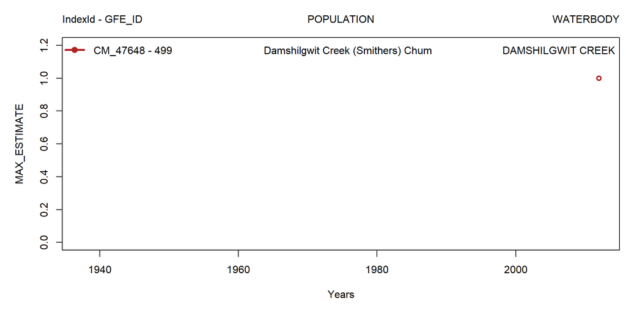

```
## [1] "The series below is/are associated to CU Adams-Early Summer (cuid = 760) in the PSE:"
```

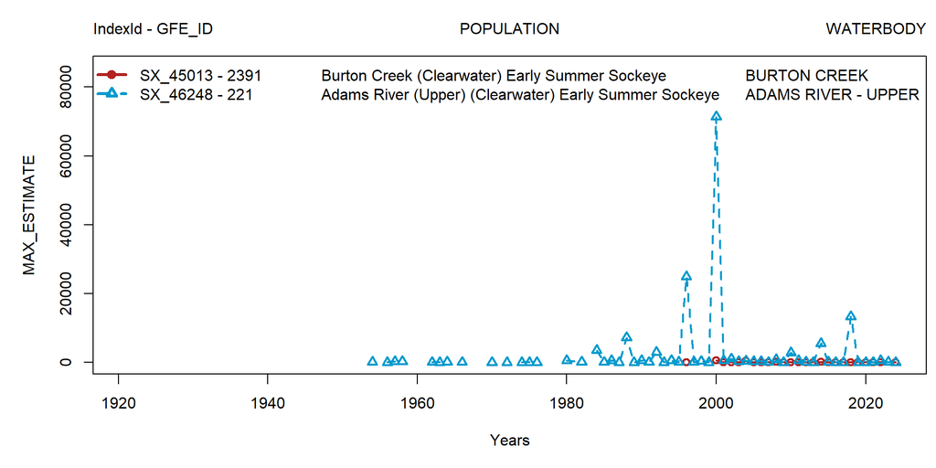

```
## [1] "The series below is/are associated to CU Momich-Early summer (cuid = 761) in the PSE:"
```

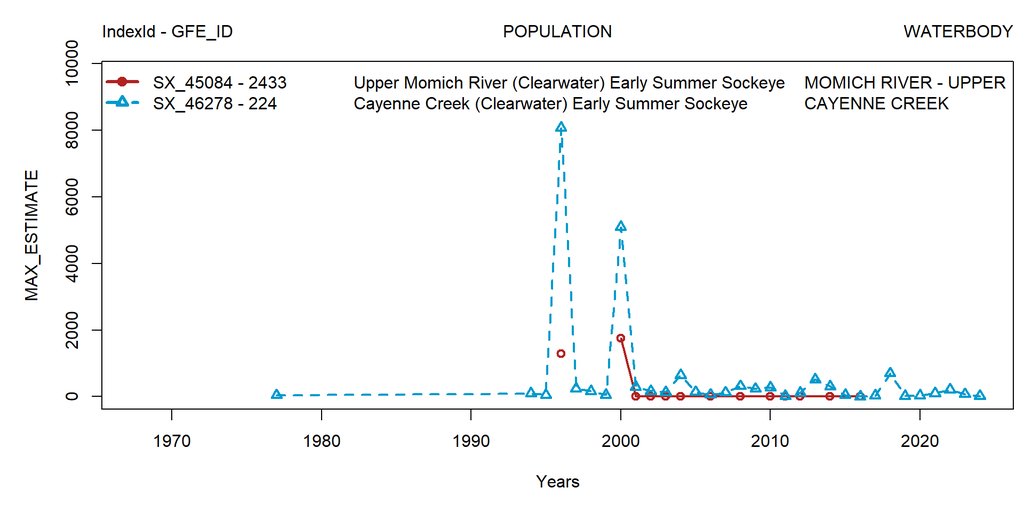

Finally, there are 2 time series with a `CU_NAME` and `FULL_CU_IN` that are not in **CUSS** and for which we could not find the corresponding `cuid` and `cu_name_pse` in the PSE:

```
##   IndexId GFE_ID FULL_CU_IN          WATERBODY       Y_LAT      X_LONGT
## 1 SX_3302   3416  SEL-13-xx GREAT CENTRAL LAKE 49.32764265 -124.9826436
## 2 SX_3302   3444  SEL-13-xx        SPROAT LAKE 49.28801087 -124.9153347
##   coordinates_from            POPULATION              CU_NAME species_name cuid
## 1             CUSS Somass System Sockeye GREAT CENTRAL/SPROAT      Sockeye   NA
## 2             CUSS Somass System Sockeye GREAT CENTRAL/SPROAT      Sockeye   NA
##   cu_name_pse
## 1        <NA>
## 2        <NA>
##                                                                  comment
## 1 CUID not found: IndexId = SEL-13-xx and CU_NAME = GREAT CENTRAL/SPROAT
## 2 CUID not found: IndexId = SEL-13-xx and CU_NAME = GREAT CENTRAL/SPROAT
##   comment_cu
## 1       <NA>
## 2       <NA>
```

```
## [1] "The series below have CU_NAME = GREAT CENTRAL/SPROAT and FULL_CU_IN = SEL-13-xx"
```

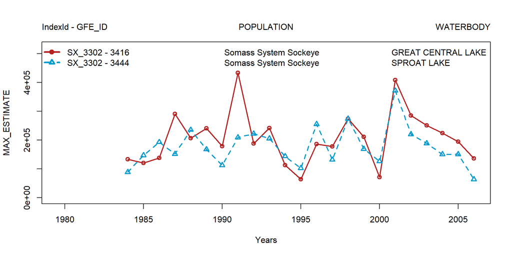

The reference of all these time series (i.e., `IndexId/POP_ID` & `GFE_ID` and associated fields) are added to **CUSS** in the next step.

### 3.6.3 Add the references of the missing time series to CUSS

First we add to **CUSS** the references of the 252 time series for which we found the `CU_NAME` and `FULL_CU_IN` in **CUSS** and the `cuid` and `cu_name_pse` in the PSE.

Second we add to **CUSS** the references of the 5 time series for which we did not find the `CU_NAME` and `FULL_CU_IN` but for which we found the `cuid` and `cu_name_pse`.

Finally, the 2 time series with a `CU_NAME` and `FULL_CU_IN` for which we could not find the corresponding `cuid` and `cu_name_pse` are added to **CUSS**.

So now all the time series in **NUSEDS** should be referenced in **CUSS**, is that true?

```
## [1] "YES :-)"
```

### 3.6.4 Find the cuid and cu_name of all the IndexId/POP_ID in CUSS and NUSEDS

In this section we attempt to find the PSE’s `cuid` and `cu_name_pse` to all CUs (`FULL_IN_IN` and `CU_NAME`) in **CUSS**. We then fill the missing information for the fields `FULL_CU_IN`, `cuid` and `cu_name_pse` in **NUSEDS**.

There are 5 time series without a `FULL_CU_IN` in **NUSEDS** and they should be the ones identified above, is that the case?

```
## [1] "YES :-)"
```

There are 86 time series and 22 `FULL_CU_IN` in **NUSEDS** for which we could not find a `cuid` and `cu_name_pse`:

```
##      IndexId  GFE_ID                        WATERBODY FULL_CU_IN
## 1    CM_1863     256             NORTH THOMPSON RIVER    CM-9004
## 2     CM_383     141                      BAKER CREEK    CM-9004
## 3   CM_46972      55                    RAILWAY CREEK    CM-9004
## 4   CM_47113     109                       RUBY CREEK    CM-9004
## 5   CM_47116     110                     HUNTER CREEK    CM-9004
## 6   CM_47120     111                 SILVERHOPE CREEK    CM-9004
## 7   CM_47124     112                 COQUIHALLA RIVER    CM-9004
## 8   CM_47131     113                     SUCKER CREEK    CM-9004
## 9   CM_47135     114                     KAWKAWA LAKE    CM-9004
## 10  CM_47136     115                     STEVEN CREEK    CM-9004
## 11  CM_47137     116                       MENZ CREEK    CM-9004
## 12  CM_47138     117                       KOPP CREEK    CM-9004
## 13  CM_47142     118                   AMERICAN CREEK    CM-9004
## 14  CM_47143     119                SQUEAH LAKE CREEK    CM-9004
```

[output cut: 159 more lines]

These series are kept in **NUSEDS**.

# 4 Trubleshoot issues

Normally, `POP_ID` and `GFE_ID` should be a ONE-TO-ONE relationship (i.e., a given population should be present in only one location and a CU should have only one population in any given location). By comparing the times series presenting either of these these two issues, we can spot clear errors in the data, errors that we solve by either deleting duplicated data points or merging time series.

## 4.1 Issue: CUs with multiple time series in a single location

CUs with multiple `IndexId/POP_ID` associated to a single `GFE_ID`.

There are many cases where a CU in a given location (i.e., a unique `GFE_ID`) is associated to multiple series (i.e. `IndexId`/`POP_ID`), which should not happen. Observing these cases reveals clear duplicated data points or single data point that are not worth keeping. To fix these issues we proceed as follow:

- **Case 1**: one of the duplicated series has only one data point:
  - if it is complementary: merge to the other (longer) series
  - if it is in conflict or a duplicate: remove the focal series
- **Case 2**: the shorter series is 100% duplicated: removed the focal series
- **Case 3**: for the rest of the duplicated series:
  - points that are conflictual or duplicated are summed up
  - points that are complementary are merged

By summing data points in a few cases, we assume that the different runs (e.g., “Chinook Run 1” and “Chinook Run 2”) can be considered a single population. For example, the Bridge River has Summer and Late run sockeye surveys, but these are both in the MIDDLE FRASER river-type sockeye CU and are summed to yield the Bridge River survey for that CU in the PSE.

The figures below show the time series before and after correction with the action made (i.e., “MERGED”, “DELETED”, “SUMMED”) indicated.

There are a few instances where a special fix is done, as indicated below in the corresponding figures.

In the few instances where data points are summed, we define the `ESTIMATE_CLASSIFICATION` (e.g., “RELATIVE ABUNDANCE (TYPE-3)”) as the value corresponding to the highest `MAX_ESTIMATE` value between the two data points. In these cases, a table follows the figure and show the data points that are summed with their corresponding `Year` and `ESTIMATE_CLASSIFICATION`.

```
##    IndexId GFE_ID FULL_CU_IN cuid
## 1   CN_275    220      CK-13  313
## 2 CN_46246    220      CK-13  313
```

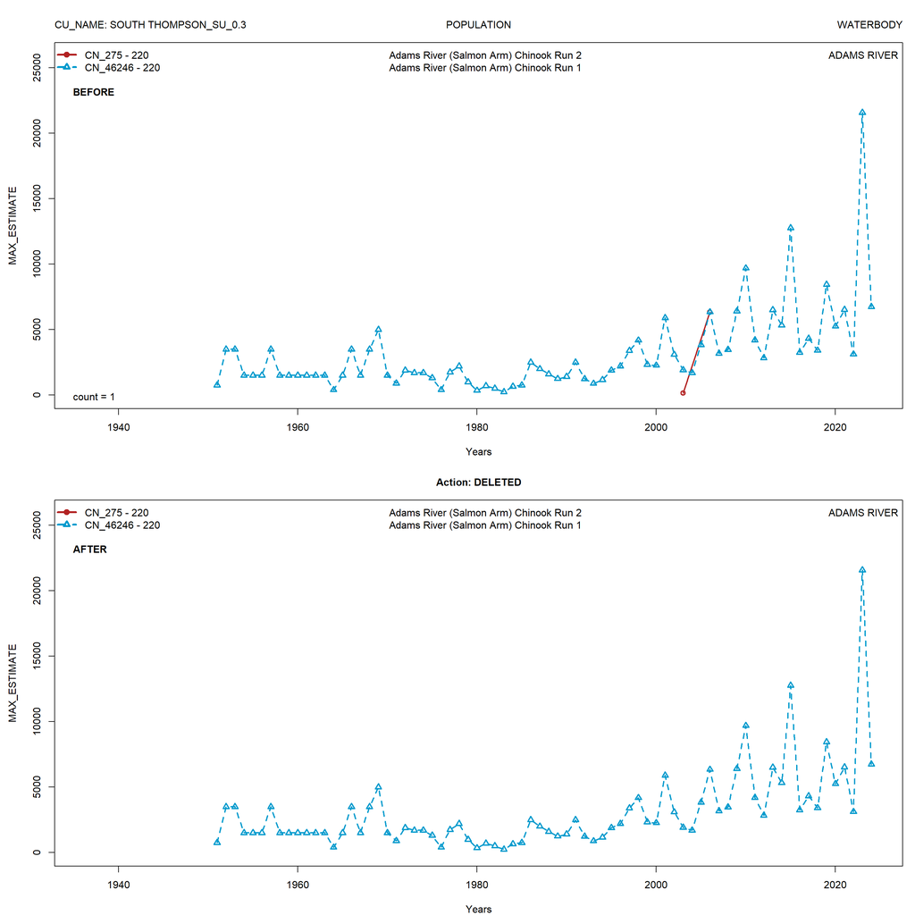

```
## [1] "Special fix (above): the two red points are deleted; one is a duplicate, the other one has 'UNKNOWN' ESTIMATE_CLASSIFICATION:"
##   GFE_ID Year IndexId_s1 MAX_ESTIMATE_s1  ESTIMATE_CLASSIFICATION_s1 IndexId_s2
## 1    220 2003     CN_275             150                     UNKNOWN   CN_46246
## 2    220 2006     CN_275            6344 RELATIVE ABUNDANCE (TYPE-4)   CN_46246
##   MAX_ESTIMATE_s2  ESTIMATE_CLASSIFICATION_s2
## 1            1920 RELATIVE ABUNDANCE (TYPE-4)
## 2            6344 RELATIVE ABUNDANCE (TYPE-4)
## [1] "***"
##    IndexId GFE_ID FULL_CU_IN cuid
## 1   CM_297     14      CM-02  701
## 2 CM_47925     14      CM-02  701
```

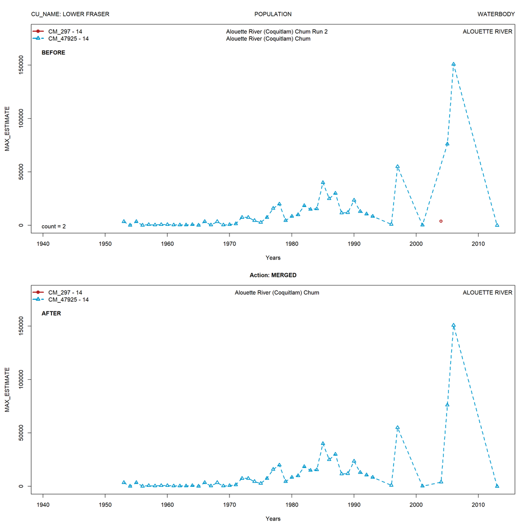

```
##   IndexId GFE_ID FULL_CU_IN cuid
## 1  SX_431    252  SEL-09-03  739
## 2 SX_7635    252  SEL-09-03  739
```

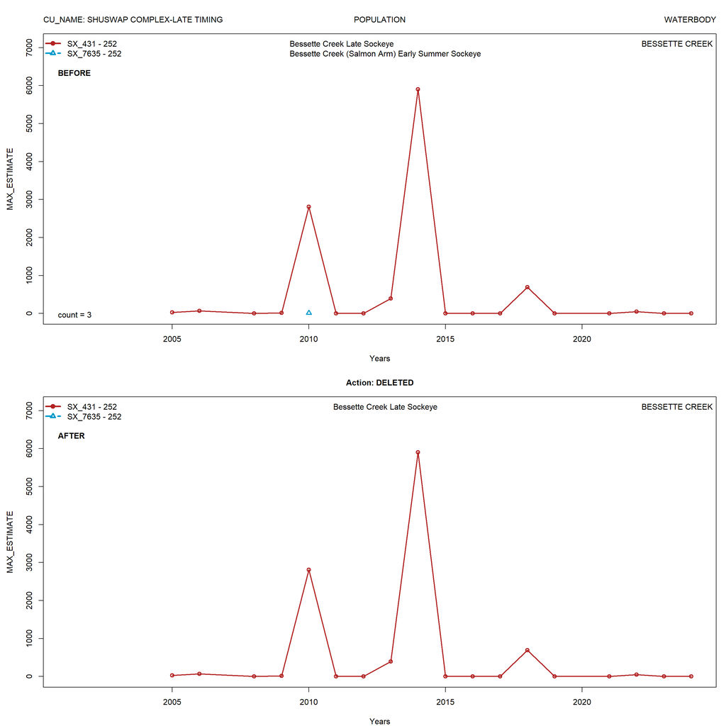

```
##    IndexId GFE_ID FULL_CU_IN cuid
## 1  CM_1251     67      CM-02  701
## 2 CM_47009     67      CM-02  701
```

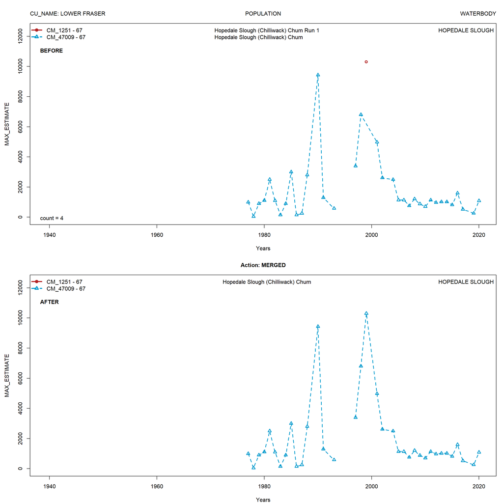

```
##    IndexId GFE_ID FULL_CU_IN cuid
## 1  CN_1416    312      CK-11  311
## 2 CN_45555    312      CK-11  311
```

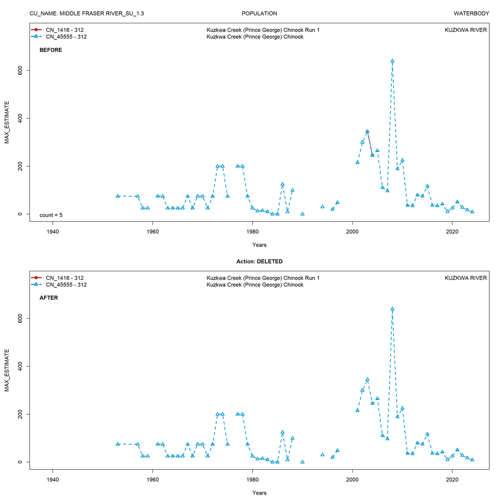

```
##    IndexId GFE_ID FULL_CU_IN cuid
## 1  CO_1720    241      CO-08  708
## 2 CO_46441    241      CO-08  708
```

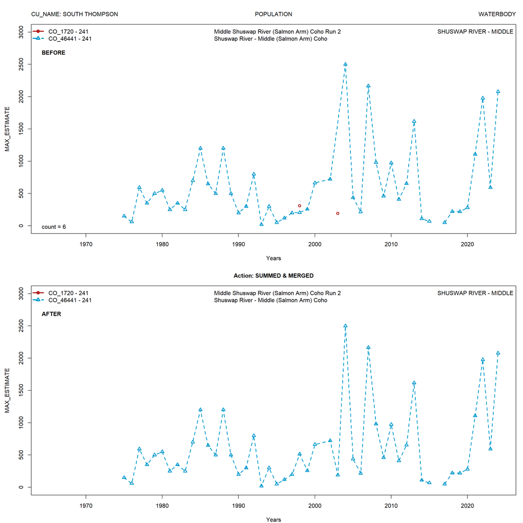

```
## [1] "Below is MAX_ESTIMATE and ESTIMATE_CLASSIFICATION for the data points summed:"
##   GFE_ID Year IndexId_s1 MAX_ESTIMATE_s1 ESTIMATE_CLASSIFICATION_s1 IndexId_s2
## 1    241 1998    CO_1720             309                    UNKNOWN   CO_46441
##   MAX_ESTIMATE_s2 ESTIMATE_CLASSIFICATION_s2
## 1             206                    UNKNOWN
## [1] "***"
##    IndexId GFE_ID FULL_CU_IN cuid
## 1  CO_2182   2476      CO-48  749
## 2 CO_44539   2476      CO-48  749
```

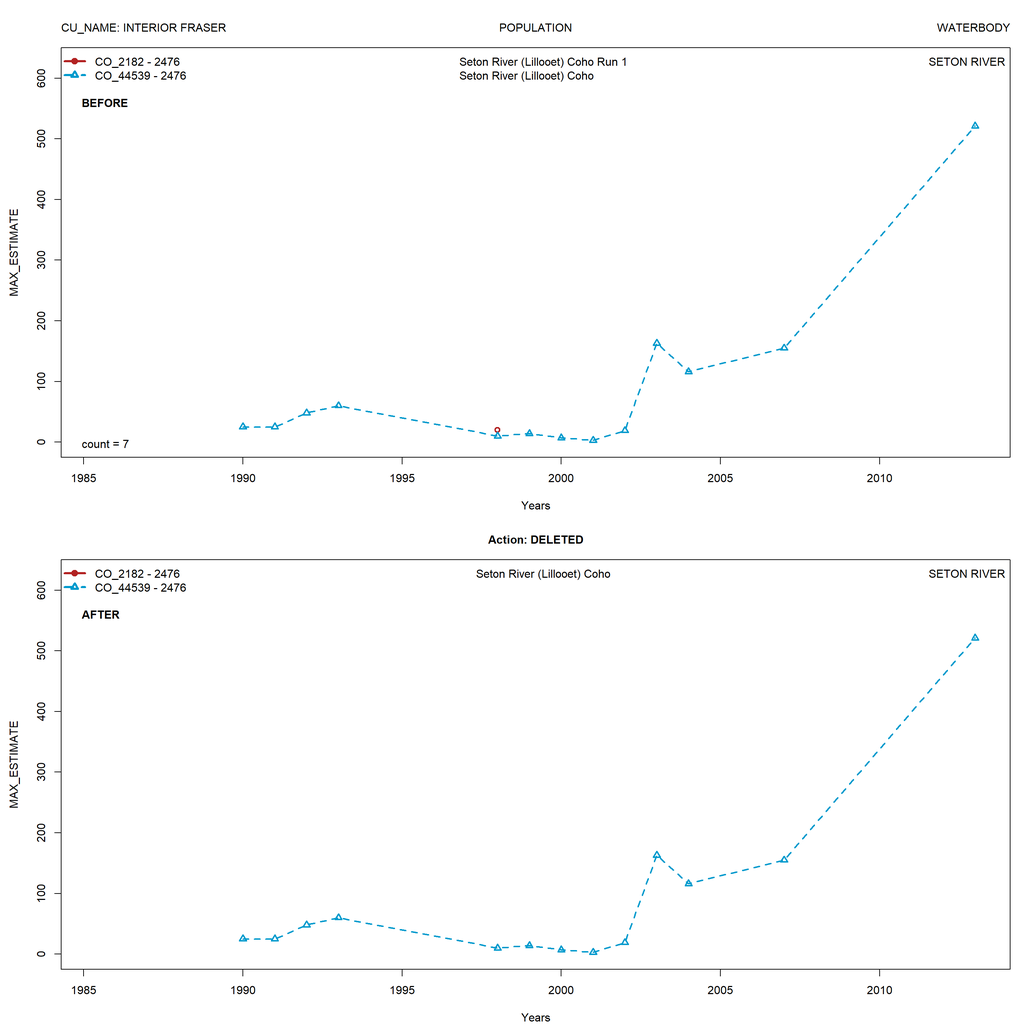

```
##    IndexId GFE_ID FULL_CU_IN cuid
## 1  CN_2318    167      CK-12  312
## 2 CN_47519    167      CK-12  312
```

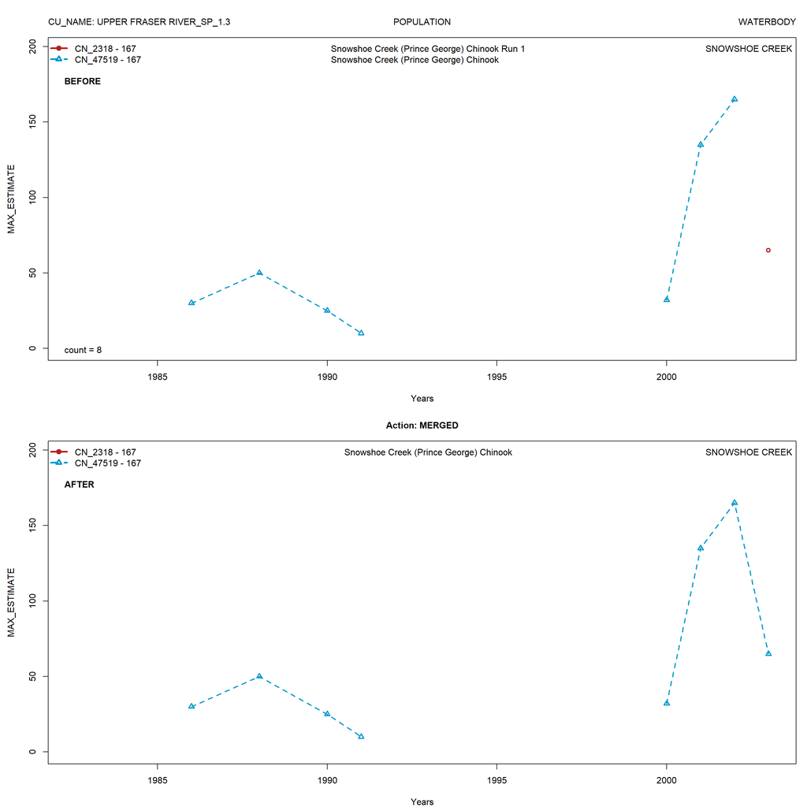

```
##    IndexId GFE_ID FULL_CU_IN cuid
## 1  CN_2483    142      CK-10  310
## 2 CN_47277    142      CK-10  310
## 3 CN_47278    142      CK-10  310
```

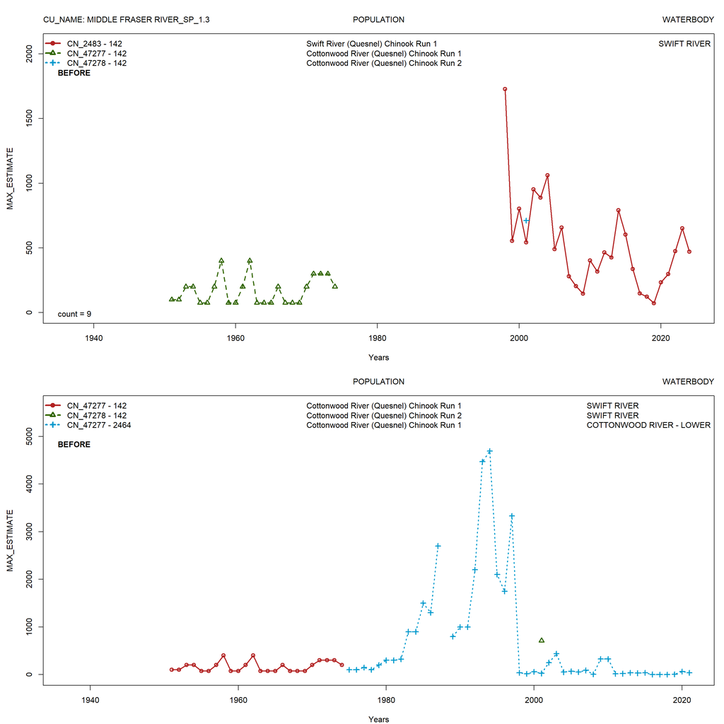

```
## [1] "we can see in the last figure above that there is another time series (CN_47277 - 2464) of the same CU associated to the COTTONWOOD RIVER, which matches the POPULATION of both CN_47277 and CN_47278."
## [1] "**DECISIONS:**"
## [1] "We merge the series CN_47277 - 142 to the series CN_47277 - 2464 by changing its GFE_ID (and associated fields) from 142 to 2464."
## [1] "The one data point of series CN_47278 - 142 is discarded because it is in conflict with series CN_47277 - 2464 (plus ESTIMATE_METHOD = 'Area Under the Curve' vs. 'Peak Live * Expansion')."
## [1] "After corrections:"
## [1] "24 rows were edited in all_areas_nuseds at the following fields: AREA, WATERBODY, GAZETTED_NAME, LOCAL_NAME_1, LOCAL_NAME_2, WATERSHED_CDE, WATERBODY_ID, GFE_ID, FWA_WATERSHED_CDE"
```

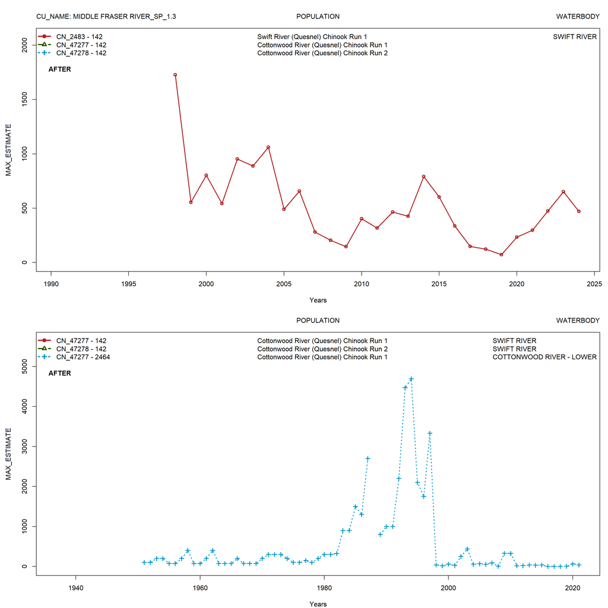

```
##   IndexId GFE_ID FULL_CU_IN cuid
## 1 CO_3136   2243      CO-22  518
## 2 CO_7776   2243      CO-22  518
```

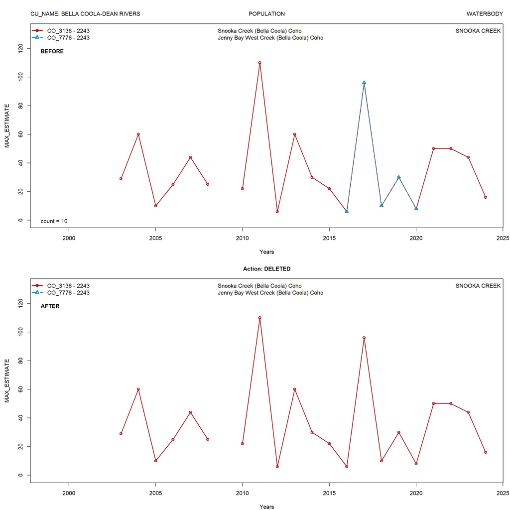

```
##   IndexId GFE_ID FULL_CU_IN cuid
## 1 CN_3306  11486      CK-31  328
## 2 CN_3324  11486      CK-31  328
```

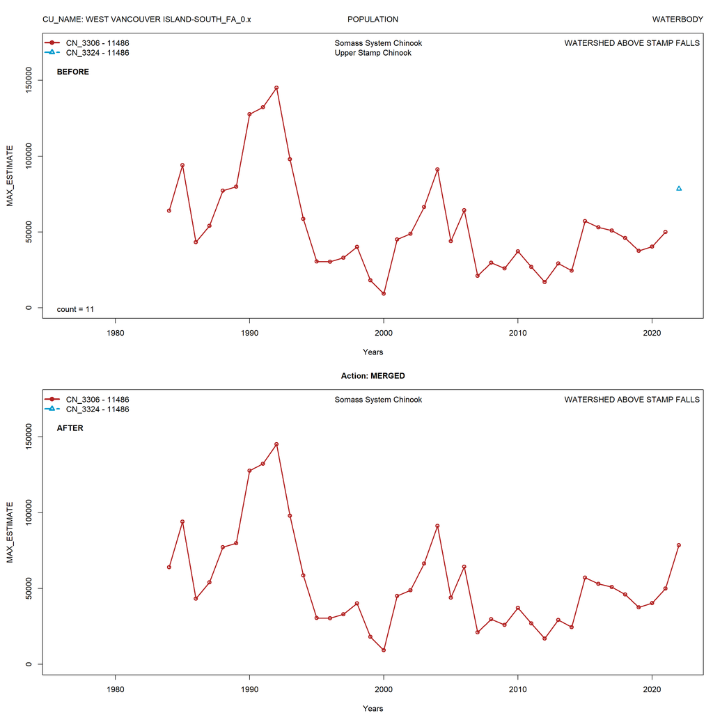

```
##   IndexId GFE_ID FULL_CU_IN cuid
## 1 CN_3306  11487      CK-31  328
## 2 CN_3320  11487      CK-31  328
```

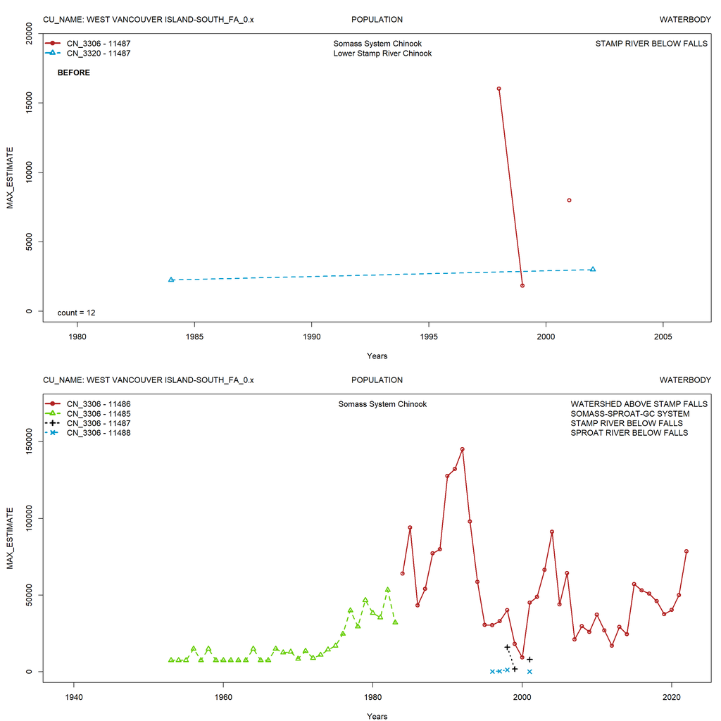

```
## [1] "The POPULATION of series CN_3306 - 11487 does not align well with WATERBODY (1st plot above)."
## [1] "Additonally, IndexId/POP_ID CN_3306 is associated to multiple GFE_ID (plot above)."
## [1] "**DECISIONS:**"
## [1] "Merge CN_3306 - 11487 to CN_3320 - 11487 in NUSEDS."
## [1] "***"
```

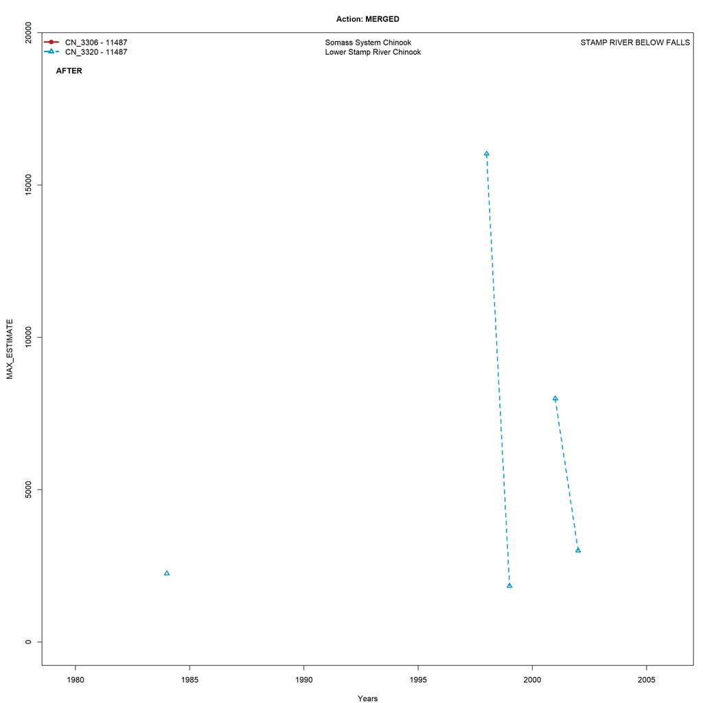

```
##    IndexId GFE_ID FULL_CU_IN cuid
## 1  CN_3331   1156      CK-27  325
## 2 CN_53069   1156      CK-27  325
```

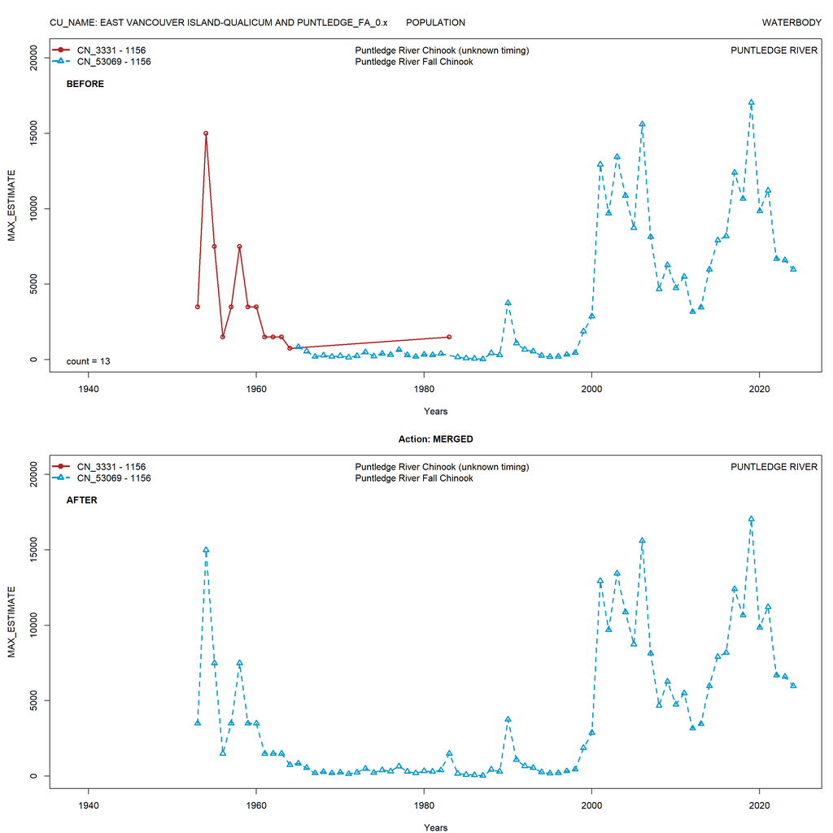

```
##    IndexId GFE_ID FULL_CU_IN cuid
## 1  CN_3333   1194      CK-83  334
## 2 CN_51518   1194      CK-83  334
```

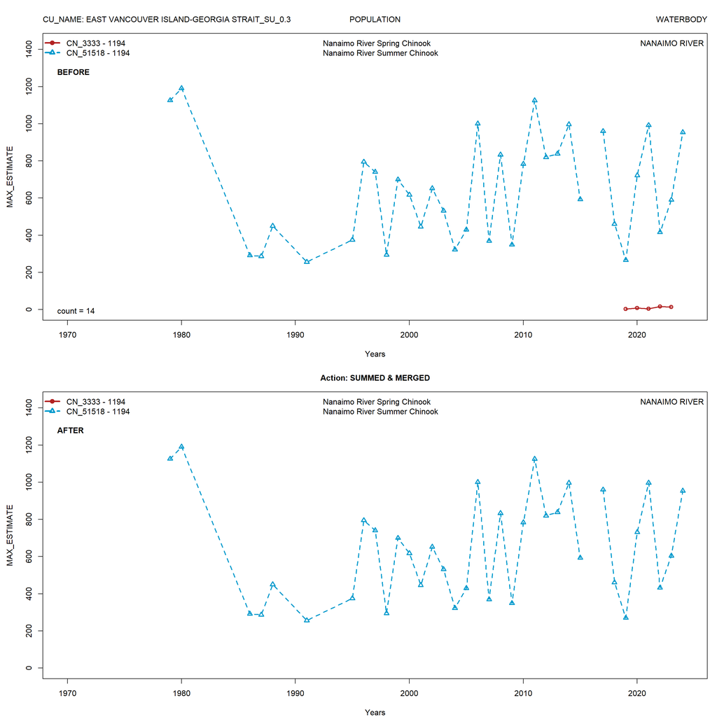

```
## [1] "Below is MAX_ESTIMATE and ESTIMATE_CLASSIFICATION for the data points summed:"
##   GFE_ID Year IndexId_s1 MAX_ESTIMATE_s1  ESTIMATE_CLASSIFICATION_s1 IndexId_s2
## 1   1194 2019    CN_3333               3 RELATIVE ABUNDANCE (TYPE-5)   CN_51518
## 2   1194 2020    CN_3333               9 RELATIVE ABUNDANCE (TYPE-5)   CN_51518
## 3   1194 2021    CN_3333               5 RELATIVE ABUNDANCE (TYPE-5)   CN_51518
## 4   1194 2022    CN_3333              16 RELATIVE ABUNDANCE (TYPE-5)   CN_51518
## 5   1194 2023    CN_3333              14 RELATIVE ABUNDANCE (TYPE-5)   CN_51518
##   MAX_ESTIMATE_s2  ESTIMATE_CLASSIFICATION_s2
## 1             267 RELATIVE ABUNDANCE (TYPE-5)
## 2             722 RELATIVE ABUNDANCE (TYPE-4)
## 3             992     TRUE ABUNDANCE (TYPE-2)
## 4             417 RELATIVE ABUNDANCE (TYPE-3)
## 5             590 RELATIVE ABUNDANCE (TYPE-3)
## [1] "***"
##    IndexId GFE_ID FULL_CU_IN cuid
## 1  CN_3334   1194      CK-25  324
## 2 CN_51519   1194      CK-25  324
```

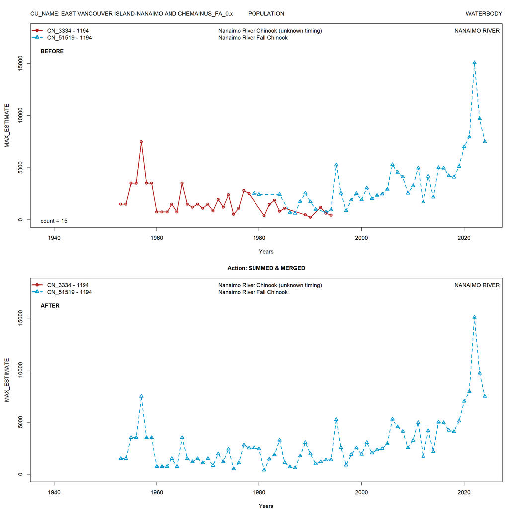

```
## [1] "Below is MAX_ESTIMATE and ESTIMATE_CLASSIFICATION for the data points summed:"
##    GFE_ID Year IndexId_s1 MAX_ESTIMATE_s1  ESTIMATE_CLASSIFICATION_s1
## 30   1194 1984    CN_3334             824 RELATIVE ABUNDANCE (TYPE-5)
## 32   1194 1989    CN_3334             483 RELATIVE ABUNDANCE (TYPE-5)
## 33   1194 1990    CN_3334             233 RELATIVE ABUNDANCE (TYPE-5)
## 35   1194 1993    CN_3334             638 RELATIVE ABUNDANCE (TYPE-5)
## 36   1194 1994    CN_3334             437 RELATIVE ABUNDANCE (TYPE-5)
##    IndexId_s2 MAX_ESTIMATE_s2  ESTIMATE_CLASSIFICATION_s2
## 30   CN_51519            2423 RELATIVE ABUNDANCE (TYPE-5)
## 32   CN_51519            2550 RELATIVE ABUNDANCE (TYPE-5)
## 33   CN_51519            1720 RELATIVE ABUNDANCE (TYPE-5)
## 35   CN_51519             740 RELATIVE ABUNDANCE (TYPE-5)
## 36   CN_51519             940 RELATIVE ABUNDANCE (TYPE-5)
## [1] "***"
## [1] "note that the POPULATION of CN_3334 (above) shows 'unkown timing', however the field END_SPAWN_DT_FROM shows that the end of the spawning season is in the FALL, which corresonds to the correct CU:"
```

[output cut: 33 more lines]

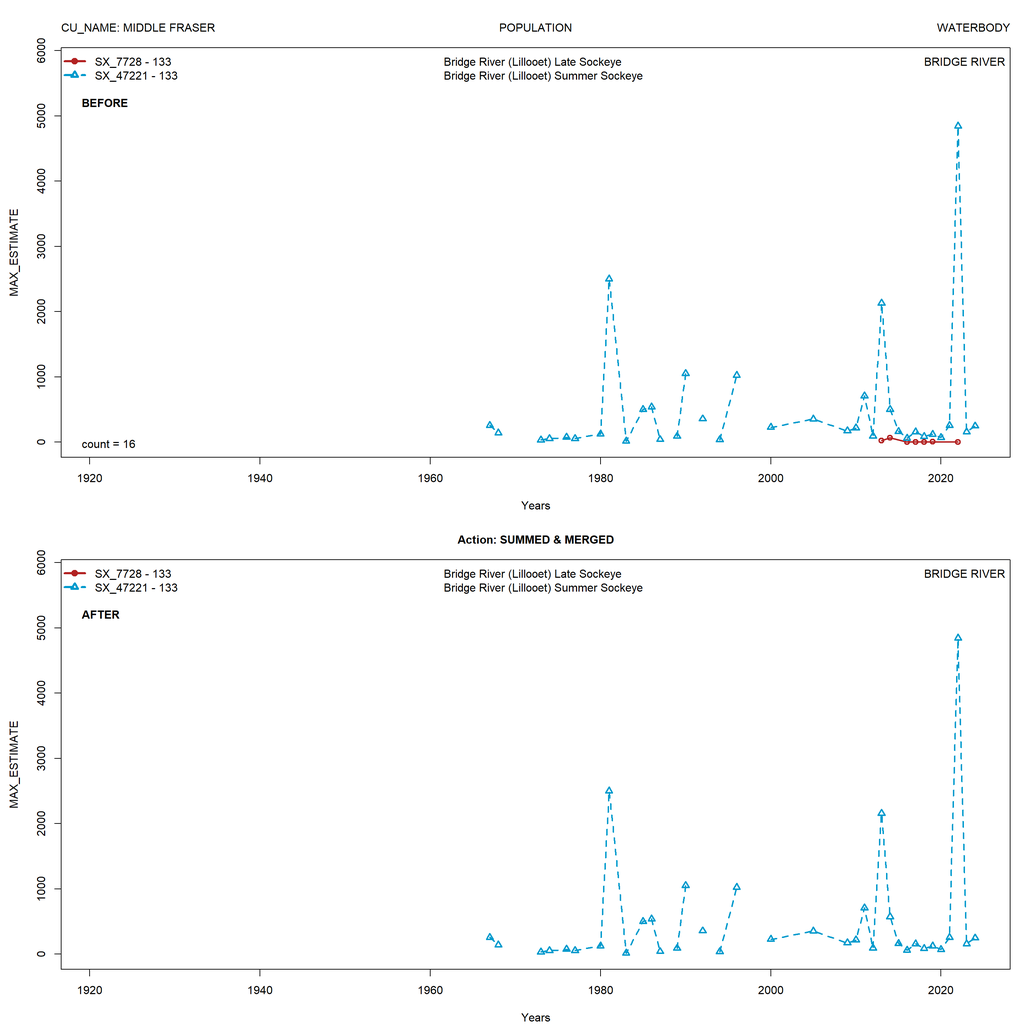

```
## [1] "Below is MAX_ESTIMATE and ESTIMATE_CLASSIFICATION for the data points summed:"
##   GFE_ID Year IndexId_s1 MAX_ESTIMATE_s1  ESTIMATE_CLASSIFICATION_s1 IndexId_s2
## 1    133 2013    SX_7728              25 RELATIVE ABUNDANCE (TYPE-4)   SX_47221
## 2    133 2014    SX_7728              68 RELATIVE ABUNDANCE (TYPE-3)   SX_47221
## 3    133 2016    SX_7728               0 RELATIVE ABUNDANCE (TYPE-4)   SX_47221
## 4    133 2017    SX_7728               0 RELATIVE ABUNDANCE (TYPE-3)   SX_47221
## 5    133 2018    SX_7728               0 RELATIVE ABUNDANCE (TYPE-3)   SX_47221
## 6    133 2019    SX_7728               4 RELATIVE ABUNDANCE (TYPE-4)   SX_47221
## 7    133 2022    SX_7728               0 RELATIVE ABUNDANCE (TYPE-4)   SX_47221
##   MAX_ESTIMATE_s2  ESTIMATE_CLASSIFICATION_s2
## 1            2131 RELATIVE ABUNDANCE (TYPE-4)
## 2             502 RELATIVE ABUNDANCE (TYPE-3)
## 3              61 RELATIVE ABUNDANCE (TYPE-3)
## 4             158 RELATIVE ABUNDANCE (TYPE-3)
## 5              88 RELATIVE ABUNDANCE (TYPE-3)
## 6             121 RELATIVE ABUNDANCE (TYPE-4)
## 7            4844 RELATIVE ABUNDANCE (TYPE-4)
## [1] "***"
##    IndexId GFE_ID FULL_CU_IN cuid
## 1  CN_7809    442      CK-01  301
## 2 CN_48442    442      CK-01  301
```

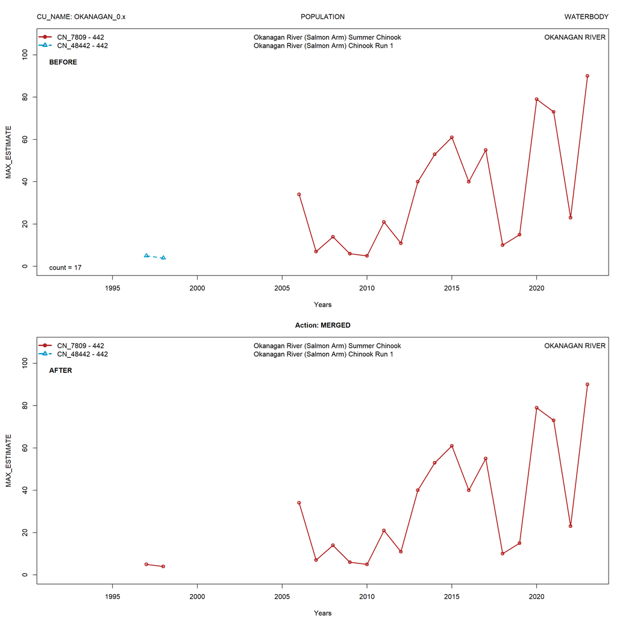

```
##    IndexId GFE_ID FULL_CU_IN cuid
## 1  SX_7823    298  SEL-06-06  753
## 2 SX_46023    298  SEL-06-06  753
```

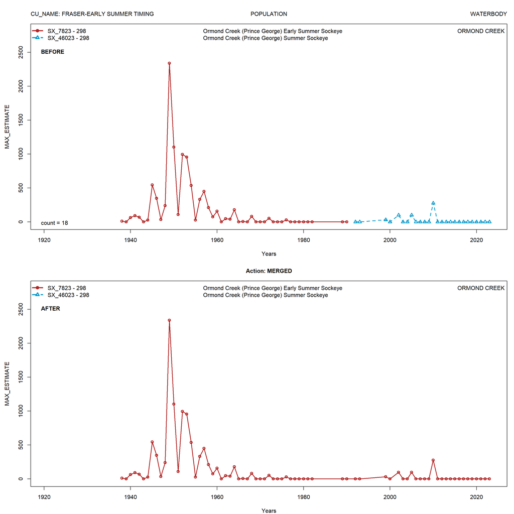

```
##    IndexId GFE_ID FULL_CU_IN cuid
## 1 CM_39896   1449      CM-11  977
## 2 CM_39897   1449      CM-11  977
```

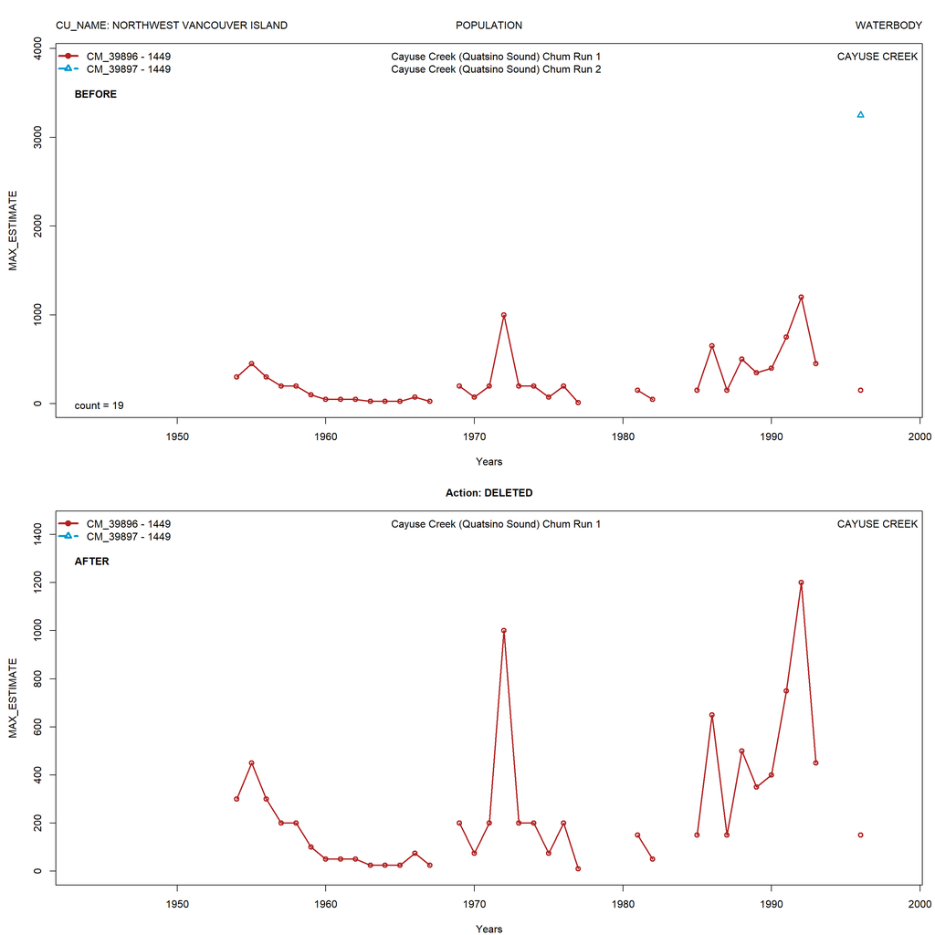